# MAD – Data Analysis & Biostatistics in R

Chapter 8 – Import Data to R

James R. Hunter, Ph.D.

DIPA, EPM, UNIFESP

2020-08-25

Importing data from spreadsheets is the primary way that you will bring data into R. We will look at the generalized case of “comma-delimited files” (“.csv”), then import files directly from Excel’s proprietary format (“.xlsx”). Finally, we will learn to import sequence files using a new, specialized package `bioseq`, that contains functions for importing and manipulating both nucleotide and amino acid sequences.

# 1 Comma-Delimited Files

The most common file type you will be importing into R is the comma-delimited file, or “csv” file. As I have previously explained, it is a basic text file that any text editor can read, but it contains its information in a structured way that allows the R function `readr::read_csv()` (**VSS:** package name followed by 2 colons followed by function name) to parse it into a meaningful R tibble.[^1]

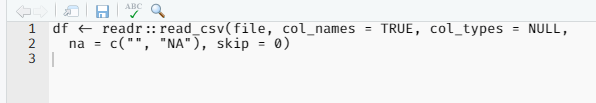

## 1.1 Side Note about Packages, Functions and Formats

In the figure above, I have used the package::function format to remind you where the function comes from. However, if you are writing a simple script with only a few lines and you know you have loaded the package into memory, it is optional. Some R people like to always use the package::function format as they always know what version of a function they are using. Frequently, different packages use the same or similar names for slightly different versions of a function and the presence of the package name in the code is helpful to keeping everything straight. In this case, the `readr` package is automatically loaded when you load the Tidyverse set of packages with `library(tidyverse)`. The figure below shows the list of packages loaded by this command.

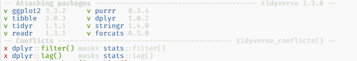

## 1.2 Arguments of the `read_csv()` Function

There are a few key arguments that you need to specify so the `read_csv()` function can find the data you want to upload to R and know how to parse it. However, I have not listed all the possible arguments here, just the most useful ones. First you need to give the data frame a name. You are going to assign a name to the tibble (“df” in the definition of `read_csv()` above) that you will refer to it by thereafter.

The first argument is the name of the file on your computer the function will be reading: `file`. The file name needs enough information about the path where the file is located to find it. This is a case where the `here::here()` function we have previously discussed comes in helpful since it defines a full path. In the example below, I will use `here()` to show you one of the ways I use to save me some pain.

“.csv” files have the option of putting the variable/column names in the first row. `read_csv()` assumes this is TRUE. If it is not, if the data does not include any variable names, then you need to set this argument to FALSE: `col_names = FALSE`.

The third argument, `col_types =`, is a bit more complicated. `read_csv()` will try to guess the correct data type for each column following R’s rules for the hierarchy of data classes. Its guesses are generally quite good if the data is straightforward. However, if you want to specify the column types, you can put a string of characters in the place of `NULL` to represent the data types using the following letters:

- c = character
- i = integer
- n = number
- d = double
- l = logical
- f = factor
- D = date
- T = date time
- t = time
- ? = guess
- - to skip the column

Make sure that you have exactly the number of characters in your string as there are columns in the file. For example, if you have a data set with five columns, the first a string, the second a factor, the third a number, the fourth a column you want to skip and the last another character string, your column type argument should be `col_types = "cfn-c"`.

The fourth argument gives you the chance to specify what characters define missing data (`NA`). `read_csv` assumes that either a blank string or the string “NA” represents missing data. If you want to add others, you need to modify the string to include the value your data set uses. For example, some social science data sets use “99” as an indicator of missing data. This doesn’t work for hard science and it is pretty bad practice in social science as well. However, if you data set includes this option, you will want to specify the `na =` argument with `na = na = c("", "NA", "99")`.

## 1.3 Example 1 - Simple Data Set

Here is a simple “.csv” file, `classe_simples.csv` that records the names, home state, age and scores on a standardized test (1 - 10).

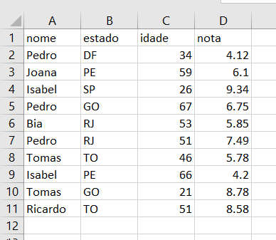

To bring this file into R, we apply the function `read_csv()` explained above. First, we give the R object we will create a name, and then provide values for the arguments if they are needed. If we are using the default value shown above and in the help screen for this command, then we can omit the argument as R will use the default value.[^2] For this data, we create the data frame `classe1` with the following command:

```r
classe1 <- read_csv(here::here("classe_simples.csv"))
classe1
```

```
## # A tibble: 10 x 4
##    nome    estado idade  nota
##    <chr>   <chr>  <dbl> <dbl>
##  1 Pedro   DF        34  4.12
##  2 Joana   PE        59  6.1
##  3 Isabel  SP        26  9.34
##  4 Pedro   GO        67  6.75
##  5 Bia     RJ        53  5.85
##  6 Pedro   RJ        51  7.49
##  7 Tomas   TO        46  5.78
##  8 Isabel  PE        66  4.2
##  9 Tomas   GO        21  8.78
## 10 Ricardo TO        51  8.58
```

We can see that `read_csv()` produced a tibble with the same values as the original `.csv` file. Because the first line contained the variable names, we could omit the `col_names =` argument. We relied on the ability of R to parse the values of the four variables correctly. We can check in the report of the tibble above that it did parse them correctly. If we had wanted to put the `col_types =` argument manually, it would have been `col_types = "ccnn"`.

## 1.4 Example 2 – More Complex Data Set

Returning to the Albert Einstein Hospital sorological tests for COVID-19 antibodies, we will now import a 99 case version of the data, `einstein_soro_tests.csv`. This is the spreadsheet.

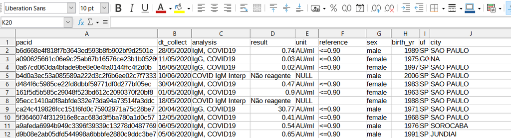

In this case, we can see the data will need some massaging to make it ready for analysis. The variable names are in the first line, so we can omit the `col_names =` argument. The patient id’s (`pacid`), while clunky with so many characters, are clearly permissible character strings. The collection date of the sample (`dt_collect`) is a Date field, but given its non-standard format[^3], R will probably parse it as a character string. We will be able to reformat it as a Date variable in our subsequent tidying phase. The `analysis` field is clearly a text string. The `result` field should be numeric, but the text entries in the field (see line 5) force R to coerce the field to a character variable. The following two fields are all character strings, although the `reference` field could be transformed into a numeric value if we want to compare it to the `result` field.

The sex field is clearly a character string. However, it has only two values, so I would like to store it as a factor – a categorical variable. To do this, instead of a “c” for character variable, I will put an “f” for a factor variable

The birth year (`birth_yr`) field will be imported as a numeric field. However, a careful look through the spreadsheet shows that there are three values of `NA`, so we will need to make sure that the `na` argument includes this value as an option. Finally, the state (`uf`) and `city` fields are character strings. Given this field-by-field analysis, we could use a `col_types =` argument of `col_types = “ccccccfncc”.

With this information, we can import the data.

```r
einstein_soro <- read_csv(here::here("einstein_soro_tests.csv"), col_types = "ccccccfncc", na = c("Não reagente", "NULL", "NA"))
glimpse(einstein_soro)
```

```
## Rows: 99
## Columns: 10
## $ pacid      <chr> "b6d668e4f818f7b3643ed593b8fb902bf9d2501e", "a090625661c...
## $ dt_collect <chr> "28/05/2020", "11/05/2020", "16/06/2020", "10/06/2020", ...
## $ analysis   <chr> "IgM, COVID19", "IgG, COVID19", "IgG, COVID19", "COVID I...
## $ result     <chr> "0.74", "0.03", "0.02", "Não reagente", "0.47", "0.9", "...
## $ unit       <chr> "AU/ml", "AU/ml", "AU/ml", NA, "AU/ml", "AU/ml", NA, "AU...
## $ reference  <chr> "<=0.90", "<=0.90", "<=0.90", "", "<=0.90", "<=0.90", ""...
## $ sex        <fct> male, female, female, male, female, female, female, male...
## $ birth_yr   <dbl> 1989, 1975, 1997, 2006, 1983, 1963, 1988, 1971, 1968, 19...
## $ uf         <chr> "SP", "GO", "SP", "SP", "SP", "SP", "SP", "SP", "SP", "S...
## $ city       <chr> "SAO PAULO", NA, "SAO PAULO", "SAO PAULO", "SAO PAULO", ...
```

Given the size of the data set, it is most useful to use `glimpse()` to view its structure[^4]. With `glimpse()`, you can see that `sex` is now a factor variable and `birth_yr` is a number.

# 2 Excel Spreadsheets (`.xlsx`)

Spreadsheets in Excel’s proprietary format can be imported directly into R without having to save them as `.csv` files first. We use the `readxl`package. Its principal function is `read_excel()`, which permits you to work with either the older “.xls” format or the current “.xlsx” format. Its overall structure is similar to that of `read_csv()`, with differences primarily related to the way it refers to column types for parsing. It also contains arguments so you can choose an individual sheet in a multi-sheet workbook or a specific region on a spreadsheet.

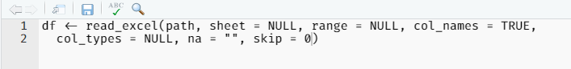

## 2.1 Arguments for `read_excel()`

As with `read_csv()`, we first give `read_excel()` the full path as the first argument. We can specify a sheet name (exactly as given in the Excel tab for that sheet in quotation marks) and then an Excel range, using the normal Excel cell reference notation (e.g., “A1:B25”) with a colon separating two beginning and end of the range. The `col_names =` argument functions the same as with `read_csv()`. The `col_types =` has the same concept as the `read_csv()` equivalent, but a different notation. As before, you will need a vector of column types that has the same length as the number of columns. If you put only one type in the argument, R will use that type for all the variables. If you omit this argument, R will guess the best type of column type to give the data in the coludatemn.

**VSS:** Stick with giving a complete list or none. When you look back on your list, you want to be clear about what you did and why. Partial lists, relying on R’s ability to recycle (i.e., repeat) column types can create some chaos.

The `na =` and `skip =` arguments function in the same way as their `read_csv()` equivalents.

## 2.2 Column Types in `read_excel()`

Column types here use whole words rather than single letters as in `read_csv()`. They include a simpler set than previously, but include all the major types we have covered so far. If you want to make a variable into a factor, for example, you will need to do it during your tidying phase as the option is not directly available here. Column types must be entered as a vector using `c()`. The column types availabe are

- date
- guess (trust R to make a good choice)
- list
- logical
- numeric
- skip
- text

## 2.3 Spreadsheet Example

As an example, we will read in one of the new standard R data sets that deals with size measurements for penguins near the Palmer Research Station in Antartica. It describes eight characteristics of 344 penguins and is in the file `penguins.xlsx`. The file only has one sheet and we will use the entire sheet.

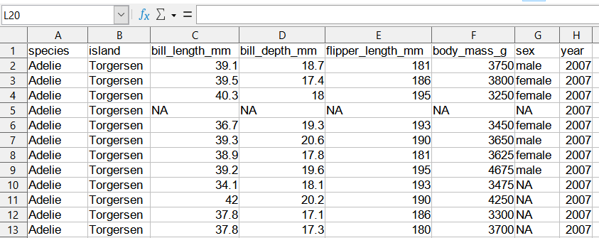

As you can see in the spreadsheet itself, some of the values are `NA`. Thus, to make sure that all the numeric values of variables such as `bill_length_mm` are stored in numeric form, we will need to specify a value for the `na =` argument of `NA`. If we do not, R will parse all the variables as “text” in `readxl`’s parlance, that is, character strings. We can correct such an error easily in the tidying phase of our work, but we can do it more efficiently here. You will note that the behavior of the `na` argument is slightly different here than in `read_csv`. Here, the argument has no default terms for missing data. In `read_csv`, the default assumes that both `NA` and a blank space indicate missingness.

If we want to specify the column types, the vector `c("text", "text", "numeric", "numeric", "numeric", "numeric", "text", "numeric)` will correctly identify the types. However, R’s parser will achieve the same result, so the argument is unnecessary.

```r
penguin <- readxl::read_excel(here::here("penguins.xlsx"), na = "NA")
glimpse(penguin)
```

```
## Rows: 344
## Columns: 8
## $ species           <chr> "Adelie", "Adelie", "Adelie", "Adelie", "Adelie",...
## $ island            <chr> "Torgersen", "Torgersen", "Torgersen", "Torgersen...
## $ bill_length_mm    <dbl> 39.1, 39.5, 40.3, NA, 36.7, 39.3, 38.9, 39.2, 34....
## $ bill_depth_mm     <dbl> 18.7, 17.4, 18.0, NA, 19.3, 20.6, 17.8, 19.6, 18....
## $ flipper_length_mm <dbl> 181, 186, 195, NA, 193, 190, 181, 195, 193, 190, ...
## $ body_mass_g       <dbl> 3750, 3800, 3250, NA, 3450, 3650, 3625, 4675, 347...
## $ sex               <chr> "male", "female", "female", NA, "female", "male",...
## $ year              <dbl> 2007, 2007, 2007, 2007, 2007, 2007, 2007, 2007, 2...
```

# 3 FASTA Files

[*If you are not a biology or medical student or you are not interested in genomic sequences, you may skip this section.*]

FASTA is the most common way to store nucleotide (DNA or RNA) and amino acid sequences in bioinformatic applications. It is a text-based representation of the sequences using the standard single-letter codes. Each sequence can be preceded by a sequence name and comments. A file of FASTA sequences is again, like a “.csv” file, a simple text file that can be read by any text editor. However, to bring FASTA formatted sequences into R for processing and analysis, we use specialized packages and functions that understand the alphabet of sequences and can separate the sequence itself from its name and comment line.

There are a number of packages that have a FASTA reading and parsing function. A new package, `bioseq` is available on CRAN and its basic reading and analysis functions remove many of the eccentricities and difficulties that other packages and functions present.

**VSS:** `bioseq` is so new that it was not in the original set of packages to be downloaded in Chapter 1. So, before you try to use this command, you need to execute the following command in the Console: `install.packages("bioseq")`.

The `read_fasta()` command only takes two arguments, the file (and its path) and the type of sequence you are loading. The default for the function is DNA, but you can specify “RNA” or “AA”, in either of these cases.

The sequence we will import is the DNA sequence of the *gag* polyprotein of the HIV virus. We will be using one of the reference genomes of HIV, the HXB-2 genome. The sequence is stored in the file “HIVHXB.fa”. This sequence is 1,503 base pairs long. In a text editor, it looks like this.

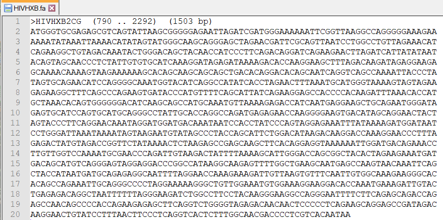

To import the file, simply execute the `read_fasta()` function with the file and sequence type.

```r
seq <- bioseq::read_fasta(here::here("HIVHXB.fa"), "DNA")
stringr::str_sub(seq, 1, 80)
```

```
## [1] "ATGGGTGCGAGAGCGTCAGTATTAAGCGGGGGAGAATTAGATCGATGGGAAAAAATTCGGTTAAGGCCAGGGGGAAAGAA"
```

`bioseq` has created a vector, `seq` of the type we requested in the command. The following line shows the first 80 nucleotides of the sequence using the Tidyverse string manipulation package `stringr`. We will do much more with sequences and `bioseq` later in this text.

[^1]: There is an equivalent function in base R, `read.csv()` that does much the same, but produces a data frame instead of a tibble.
[^2]: R’s tooltips will also guide you through the possible arguments you can apply to the command.
[^3]: Standard format is generally considered to be YYYY-mm-dd, the four-digit year, the two-digit month and the two-digit day number all separated by hyphens. If we attempted to import the `dt_collect` variable as a Date, it would fail, report a “parsing error” and insert an `NA` in the field.
[^4]: If you want to see the entire data frame, you can click on the data frame name in the `Environment`pane of RStudio. A tab will open up in the upper left section of RStudio with the entire data set in a spreadsheet-like format. This underused capability of RStudio is actually important when you need to look at the range of values each variable has.